# Sarasota County Schools Project

Angela Kothe

11/12/2021

I made maps of high schools in Sarasota County overlaid with racial data from the United States Census Bureau, to investigate where schools are positioned in comparison to racial and ethnic minorities in the County.

I began by making a bubble map of minority groups. It shows the number of Hispanic, black, and Asian residents in a given census tract. The size of the bubble represents the groups as a proportion of the tract’s population. The map shows a clear increase in black and Hispanic residents in more northern parts of Sarasota.

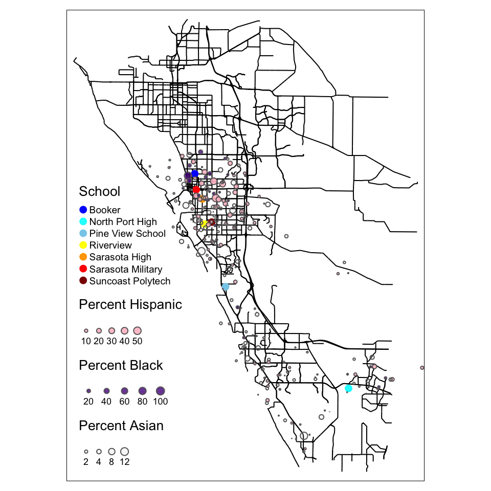

I have also separated the data out as choropleths, with the schools as distinct points layered on top.

Below I have a map of Hispanic residents in Sarasota County. Sarasota County is 9.6% Hispanic, according to the US Census Bureau. Notice that the distribution appears in clusters of tracts, for the most part.

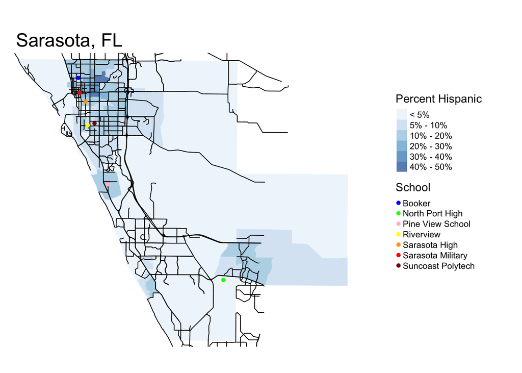

There is also a map of black residents in Sarasota County. Black residents make up 4.7% of the County’s population. Notice that most of the census tracts have a black population of 15% or less, yet there is a sharp increase in the north. In North Sarasota there is a cluster of tracts between 30 and 60%, and an outlier at over 80%.

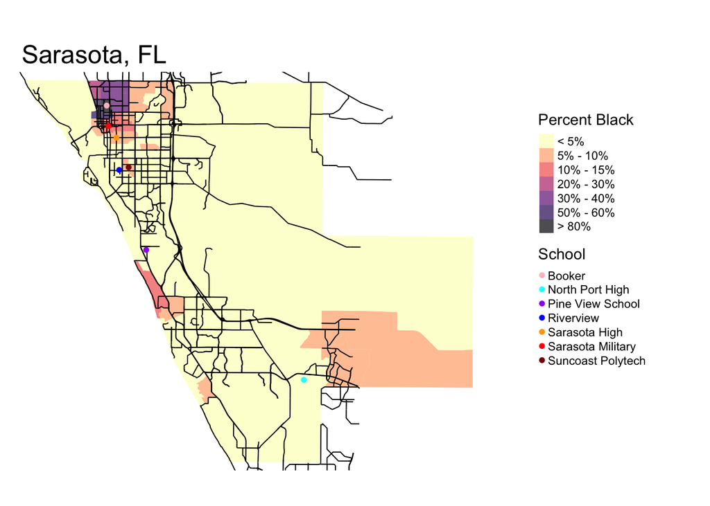

Lastly, there is a map of high schools and Asian residents. 1.6% of Sarasota County residents are Asian and the proportion peaks at around 11%. Notice that the population is very spread out.

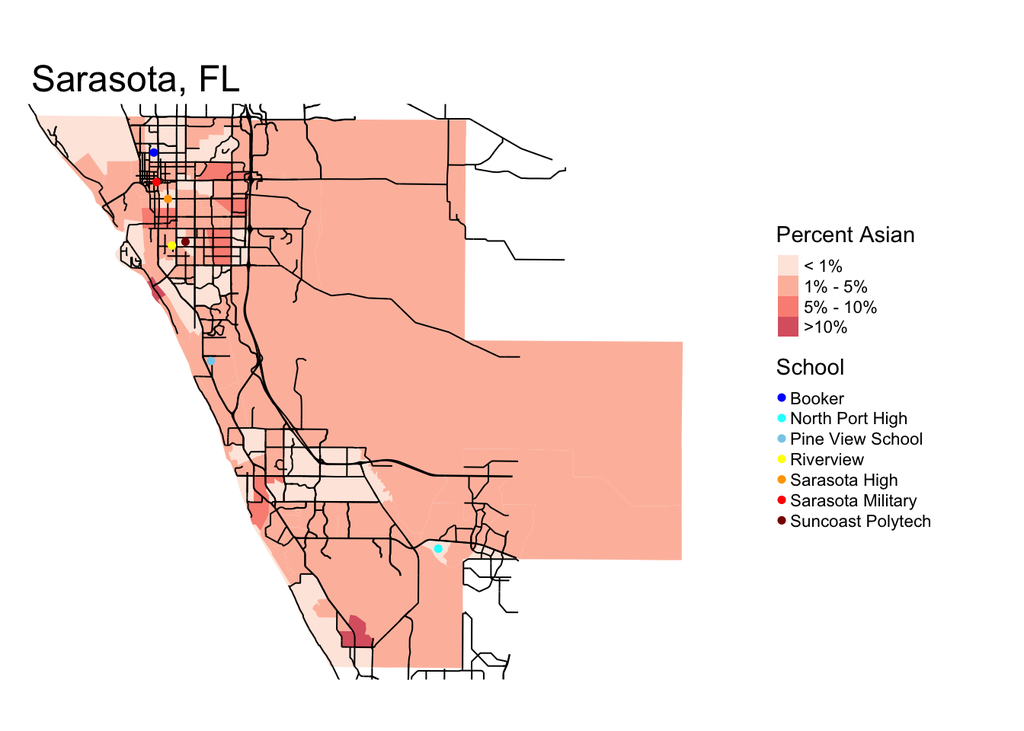

The purpose of this project was to test a hypothesis about the origins of stereotypes in Sarasota high schools. I often heard that Booker was the worst high school in the County, despite test scores indicating otherwise. I wanted visual test if these opinions possibly arise from Booker’s location in an area with many black Sarasotans.

If we look back at the map I made of the proportion of black residents in the County, we can see that Booker High is in a census tract where 82% of the residents are black. It is also surrounded by other census tracts with abnormally high proportions of black residents in comparison to other tracts. This is not sufficient to confirm by suspicions, but it is an interesting result.

These maps were made with a combination of the tmap and OpenStreetMaps packages. I first made a bounding box with roadways in the Greater Sarasota area. I used this as a basemap for the project. I then used data from the US Census Bureau and the tigris package to add data to the map. Using the tigris package allowed me to add the proper spatial data to the census tracts. I displayed this data using tmap because of its clear layering features.